# Module: filters.rank

[output not shown]

## autolevel

**`skimage.filters.rank.autolevel(image, selem, out=None, mask=None, shift_x=False, shift_y=False, shift_z=False)` [[source]](https://github.com/scikit-image/scikit-image/blob/v0.18.0/skimage/filters/rank/generic.py#L337-L387)**

Auto-level image using local histogram.

This filter locally stretches the histogram of gray values to cover the entire range of values from “white” to “black”.

**Parameters**

**`image([P,] M, N) ndarray (uint8, uint16)`**

Input image.

**`selemndarray`**

The neighborhood expressed as an ndarray of 1’s and 0’s.

**`out([P,] M, N) array (same dtype as input)`**

If None, a new array is allocated.

**`maskndarray (integer or float), optional`**

Mask array that defines (>0) area of the image included in the local neighborhood. If None, the complete image is used (default).

**`shift_x, shift_y, shift_zint`**

Offset added to the structuring element center point. Shift is bounded to the structuring element sizes (center must be inside the given structuring element).

**Returns**

**`out([P,] M, N) ndarray (same dtype as input image)`**

Output image.

#### Examples

```
>>> from skimage import data
>>> from skimage.morphology import disk, ball
>>> from skimage.filters.rank import autolevel
>>> import numpy as np
>>> img = data.camera()
>>> volume = np.random.randint(0, 255, size=(10,10,10), dtype=np.uint8)
>>> auto = autolevel(img, disk(5))
>>> auto_vol = autolevel(volume, ball(5))
```

### Examples using `skimage.filters.rank.autolevel`

[Rank filters](https://scikit-image.org/docs/0.18.x/auto_examples/applications/plot_rank_filters.html#sphx-glr-auto-examples-applications-plot-rank-filters-py)

## autolevel_percentile

**`skimage.filters.rank.autolevel_percentile(image, selem, out=None, mask=None, shift_x=False, shift_y=False, p0=0, p1=1)` [[source]](https://github.com/scikit-image/scikit-image/blob/v0.18.0/skimage/filters/rank/_percentile.py#L48-L85)**

Return greyscale local autolevel of an image.

This filter locally stretches the histogram of greyvalues to cover the entire range of values from “white” to “black”.

Only greyvalues between percentiles [p0, p1] are considered in the filter.

**Parameters**

**`image2-D array (uint8, uint16)`**

Input image.

**`selem2-D array`**

The neighborhood expressed as a 2-D array of 1’s and 0’s.

**`out2-D array (same dtype as input)`**

If None, a new array is allocated.

**`maskndarray`**

Mask array that defines (>0) area of the image included in the local neighborhood. If None, the complete image is used (default).

**`shift_x, shift_yint`**

Offset added to the structuring element center point. Shift is bounded to the structuring element sizes (center must be inside the given structuring element).

**`p0, p1float in [0, …, 1]`**

Define the [p0, p1] percentile interval to be considered for computing the value.

**Returns**

**`out2-D array (same dtype as input image)`**

Output image.

### Examples using `skimage.filters.rank.autolevel_percentile`

[Rank filters](https://scikit-image.org/docs/0.18.x/auto_examples/applications/plot_rank_filters.html#sphx-glr-auto-examples-applications-plot-rank-filters-py)

## bottomhat

**`skimage.filters.rank.bottomhat(image, selem, out=None, mask=None, shift_x=False, shift_y=False)` [[source]](https://github.com/scikit-image/scikit-image/blob/v0.18.0/skimage/filters/rank/generic.py#L390-L443)**

Local bottom-hat of an image.

This filter computes the morphological closing of the image and then subtracts the result from the original image.

**Parameters**

**`image2-D array (integer or float)`**

Input image.

**`selem2-D array (integer or float)`**

The neighborhood expressed as a 2-D array of 1’s and 0’s.

**`out2-D array (integer or float), optional`**

If None, a new array is allocated.

**`maskndarray (integer or float), optional`**

Mask array that defines (>0) area of the image included in the local neighborhood. If None, the complete image is used (default).

**`shift_x, shift_yint, optional`**

Offset added to the structuring element center point. Shift is bounded to the structuring element sizes (center must be inside the given structuring element).

**Returns**

**`out2-D array (same dtype as input image)`**

Output image.

**Warns**

**Deprecated:**

New in version 0.17.

This function is deprecated and will be removed in scikit-image 0.19. This filter was misnamed and we believe that the usefulness is narrow.

#### Examples

```
>>> from skimage import data
>>> from skimage.morphology import disk
>>> from skimage.filters.rank import bottomhat
>>> img = data.camera()
>>> out = bottomhat(img, disk(5))
```

## enhance_contrast

**`skimage.filters.rank.enhance_contrast(image, selem, out=None, mask=None, shift_x=False, shift_y=False, shift_z=False)` [[source]](https://github.com/scikit-image/scikit-image/blob/v0.18.0/skimage/filters/rank/generic.py#L937-L988)**

Enhance contrast of an image.

This replaces each pixel by the local maximum if the pixel gray value is closer to the local maximum than the local minimum. Otherwise it is replaced by the local minimum.

**Parameters**

**`image([P,] M, N) ndarray (uint8, uint16)`**

Input image.

**`selemndarray`**

The neighborhood expressed as an ndarray of 1’s and 0’s.

**`out([P,] M, N) array (same dtype as input)`**

If None, a new array is allocated.

**`maskndarray (integer or float), optional`**

Mask array that defines (>0) area of the image included in the local neighborhood. If None, the complete image is used (default).

**`shift_x, shift_y, shift_zint`**

Offset added to the structuring element center point. Shift is bounded to the structuring element sizes (center must be inside the given structuring element).

**Returns**

**`out([P,] M, N) ndarray (same dtype as input image)`**

Output image

#### Examples

```
>>> from skimage import data
>>> from skimage.morphology import disk, ball
>>> from skimage.filters.rank import enhance_contrast
>>> import numpy as np
>>> img = data.camera()
>>> volume = np.random.randint(0, 255, size=(10,10,10), dtype=np.uint8)
>>> out = enhance_contrast(img, disk(5))
>>> out_vol = enhance_contrast(volume, ball(5))
```

### Examples using `skimage.filters.rank.enhance_contrast`

[Rank filters](https://scikit-image.org/docs/0.18.x/auto_examples/applications/plot_rank_filters.html#sphx-glr-auto-examples-applications-plot-rank-filters-py)

## enhance_contrast_percentile

**`skimage.filters.rank.enhance_contrast_percentile(image, selem, out=None, mask=None, shift_x=False, shift_y=False, p0=0, p1=1)` [[source]](https://github.com/scikit-image/scikit-image/blob/v0.18.0/skimage/filters/rank/_percentile.py#L199-L237)**

Enhance contrast of an image.

This replaces each pixel by the local maximum if the pixel greyvalue is closer to the local maximum than the local minimum. Otherwise it is replaced by the local minimum.

Only greyvalues between percentiles [p0, p1] are considered in the filter.

**Parameters**

**`image2-D array (uint8, uint16)`**

Input image.

**`selem2-D array`**

The neighborhood expressed as a 2-D array of 1’s and 0’s.

**`out2-D array (same dtype as input)`**

If None, a new array is allocated.

**`maskndarray`**

Mask array that defines (>0) area of the image included in the local neighborhood. If None, the complete image is used (default).

**`shift_x, shift_yint`**

Offset added to the structuring element center point. Shift is bounded to the structuring element sizes (center must be inside the given structuring element).

**`p0, p1float in [0, …, 1]`**

Define the [p0, p1] percentile interval to be considered for computing the value.

**Returns**

**`out2-D array (same dtype as input image)`**

Output image.

### Examples using `skimage.filters.rank.enhance_contrast_percentile`

[Rank filters](https://scikit-image.org/docs/0.18.x/auto_examples/applications/plot_rank_filters.html#sphx-glr-auto-examples-applications-plot-rank-filters-py)

## entropy

**`skimage.filters.rank.entropy(image, selem, out=None, mask=None, shift_x=False, shift_y=False, shift_z=False)` [[source]](https://github.com/scikit-image/scikit-image/blob/v0.18.0/skimage/filters/rank/generic.py#L1290-L1346)**

Local entropy.

The entropy is computed using base 2 logarithm i.e. the filter returns the minimum number of bits needed to encode the local gray level distribution.

**Parameters**

**`image([P,] M, N) ndarray (uint8, uint16)`**

Input image.

**`selemndarray`**

The neighborhood expressed as an ndarray of 1’s and 0’s.

**`out([P,] M, N) array (same dtype as input)`**

If None, a new array is allocated.

**`maskndarray (integer or float), optional`**

Mask array that defines (>0) area of the image included in the local neighborhood. If None, the complete image is used (default).

**`shift_x, shift_y, shift_zint`**

Offset added to the structuring element center point. Shift is bounded to the structuring element sizes (center must be inside the given structuring element).

**Returns**

**`out([P,] M, N) ndarray (float)`**

Output image.

#### References

**`1`**

https://en.wikipedia.org/wiki/Entropy_(information_theory)

#### Examples

```
>>> from skimage import data
>>> from skimage.filters.rank import entropy
>>> from skimage.morphology import disk, ball
>>> import numpy as np
>>> img = data.camera()
>>> volume = np.random.randint(0, 255, size=(10,10,10), dtype=np.uint8)
>>> ent = entropy(img, disk(5))
>>> ent_vol = entropy(volume, ball(5))
```

### Examples using `skimage.filters.rank.entropy`

[figure not shown]

[Tinting gray-scale images](https://scikit-image.org/docs/0.18.x/auto_examples/color_exposure/plot_tinting_grayscale_images.html#sphx-glr-auto-examples-color-exposure-plot-tinting-grayscale-images-py)

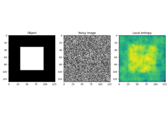

[Entropy](https://scikit-image.org/docs/0.18.x/auto_examples/filters/plot_entropy.html#sphx-glr-auto-examples-filters-plot-entropy-py)

[Rank filters](https://scikit-image.org/docs/0.18.x/auto_examples/applications/plot_rank_filters.html#sphx-glr-auto-examples-applications-plot-rank-filters-py)

## equalize

**`skimage.filters.rank.equalize(image, selem, out=None, mask=None, shift_x=False, shift_y=False, shift_z=False)` [[source]](https://github.com/scikit-image/scikit-image/blob/v0.18.0/skimage/filters/rank/generic.py#L446-L493)**

Equalize image using local histogram.

**Parameters**

**`image([P,] M, N) ndarray (uint8, uint16)`**

Input image.

**`selemndarray`**

The neighborhood expressed as an ndarray of 1’s and 0’s.

**`out([P,] M, N) array (same dtype as input)`**

If None, a new array is allocated.

**`maskndarray (integer or float), optional`**

Mask array that defines (>0) area of the image included in the local neighborhood. If None, the complete image is used (default).

**`shift_x, shift_y, shift_zint`**

Offset added to the structuring element center point. Shift is bounded to the structuring element sizes (center must be inside the given structuring element).

**Returns**

**`out([P,] M, N) ndarray (same dtype as input image)`**

Output image.

#### Examples

```
>>> from skimage import data
>>> from skimage.morphology import disk, ball
>>> from skimage.filters.rank import equalize
>>> import numpy as np
>>> img = data.camera()
>>> volume = np.random.randint(0, 255, size=(10,10,10), dtype=np.uint8)
>>> equ = equalize(img, disk(5))
>>> equ_vol = equalize(volume, ball(5))
```

### Examples using `skimage.filters.rank.equalize`

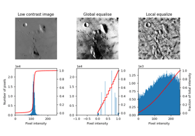

[Local Histogram Equalization](https://scikit-image.org/docs/0.18.x/auto_examples/color_exposure/plot_local_equalize.html#sphx-glr-auto-examples-color-exposure-plot-local-equalize-py)

[Rank filters](https://scikit-image.org/docs/0.18.x/auto_examples/applications/plot_rank_filters.html#sphx-glr-auto-examples-applications-plot-rank-filters-py)

## geometric_mean

**`skimage.filters.rank.geometric_mean(image, selem, out=None, mask=None, shift_x=False, shift_y=False, shift_z=False)` [[source]](https://github.com/scikit-image/scikit-image/blob/v0.18.0/skimage/filters/rank/generic.py#L655-L707)**

Return local geometric mean of an image.

**Parameters**

**`image([P,] M, N) ndarray (uint8, uint16)`**

Input image.

**`selemndarray`**

The neighborhood expressed as an ndarray of 1’s and 0’s.

**`out([P,] M, N) array (same dtype as input)`**

If None, a new array is allocated.

**`maskndarray (integer or float), optional`**

Mask array that defines (>0) area of the image included in the local neighborhood. If None, the complete image is used (default).

**`shift_x, shift_y, shift_zint`**

Offset added to the structuring element center point. Shift is bounded to the structuring element sizes (center must be inside the given structuring element).

**Returns**

**`out([P,] M, N) ndarray (same dtype as input image)`**

Output image.

#### References

**`1`**

Gonzalez, R. C. and Wood, R. E. “Digital Image Processing (3rd Edition).” Prentice-Hall Inc, 2006.

#### Examples

```
>>> from skimage import data
>>> from skimage.morphology import disk, ball
>>> from skimage.filters.rank import mean
>>> import numpy as np
>>> img = data.camera()
>>> volume = np.random.randint(0, 255, size=(10,10,10), dtype=np.uint8)
>>> avg = geometric_mean(img, disk(5))
>>> avg_vol = geometric_mean(volume, ball(5))
```

## gradient

**`skimage.filters.rank.gradient(image, selem, out=None, mask=None, shift_x=False, shift_y=False, shift_z=False)` [[source]](https://github.com/scikit-image/scikit-image/blob/v0.18.0/skimage/filters/rank/generic.py#L496-L543)**

Return local gradient of an image (i.e. local maximum - local minimum).

**Parameters**

**`image([P,] M, N) ndarray (uint8, uint16)`**

Input image.

**`selemndarray`**

The neighborhood expressed as an ndarray of 1’s and 0’s.

**`out([P,] M, N) array (same dtype as input)`**

If None, a new array is allocated.

**`maskndarray (integer or float), optional`**

Mask array that defines (>0) area of the image included in the local neighborhood. If None, the complete image is used (default).

**`shift_x, shift_y, shift_zint`**

Offset added to the structuring element center point. Shift is bounded to the structuring element sizes (center must be inside the given structuring element).

**Returns**

**`out([P,] M, N) ndarray (same dtype as input image)`**

Output image.

#### Examples

```
>>> from skimage import data
>>> from skimage.morphology import disk, ball
>>> from skimage.filters.rank import gradient
>>> import numpy as np
>>> img = data.camera()
>>> volume = np.random.randint(0, 255, size=(10,10,10), dtype=np.uint8)
>>> out = gradient(img, disk(5))
>>> out_vol = gradient(volume, ball(5))
```

### Examples using `skimage.filters.rank.gradient`

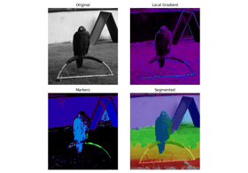

[Markers for watershed transform](https://scikit-image.org/docs/0.18.x/auto_examples/segmentation/plot_marked_watershed.html#sphx-glr-auto-examples-segmentation-plot-marked-watershed-py)

[Rank filters](https://scikit-image.org/docs/0.18.x/auto_examples/applications/plot_rank_filters.html#sphx-glr-auto-examples-applications-plot-rank-filters-py)

## gradient_percentile

**`skimage.filters.rank.gradient_percentile(image, selem, out=None, mask=None, shift_x=False, shift_y=False, p0=0, p1=1)` [[source]](https://github.com/scikit-image/scikit-image/blob/v0.18.0/skimage/filters/rank/_percentile.py#L88-L122)**

Return local gradient of an image (i.e. local maximum - local minimum).

Only greyvalues between percentiles [p0, p1] are considered in the filter.

**Parameters**

**`image2-D array (uint8, uint16)`**

Input image.

**`selem2-D array`**

The neighborhood expressed as a 2-D array of 1’s and 0’s.

**`out2-D array (same dtype as input)`**

If None, a new array is allocated.

**`maskndarray`**

Mask array that defines (>0) area of the image included in the local neighborhood. If None, the complete image is used (default).

**`shift_x, shift_yint`**

Offset added to the structuring element center point. Shift is bounded to the structuring element sizes (center must be inside the given structuring element).

**`p0, p1float in [0, …, 1]`**

Define the [p0, p1] percentile interval to be considered for computing the value.

**Returns**

**`out2-D array (same dtype as input image)`**

Output image.

## majority

**`skimage.filters.rank.majority(image, selem, *, out=None, mask=None, shift_x=False, shift_y=False, shift_z=False)` [[source]](https://github.com/scikit-image/scikit-image/blob/v0.18.0/skimage/filters/rank/generic.py#L1460-L1508)**

Majority filter assign to each pixel the most occuring value within its neighborhood.

**Parameters**

**`imagendarray`**

Image array (uint8, uint16 array).

**`selem2-D array (integer or float)`**

The neighborhood expressed as a 2-D array of 1’s and 0’s.

**`outndarray (integer or float), optional`**

If None, a new array will be allocated.

**`maskndarray (integer or float), optional`**

Mask array that defines (>0) area of the image included in the local neighborhood. If None, the complete image is used (default).

**`shift_x, shift_yint, optional`**

Offset added to the structuring element center point. Shift is bounded to the structuring element sizes (center must be inside the given structuring element).

**Returns**

**`out2-D array (same dtype as input image)`**

Output image.

#### Examples

```
>>> from skimage import data
>>> from skimage.filters.rank import majority
>>> from skimage.morphology import disk, ball
>>> import numpy as np
>>> img = data.camera()
>>> volume = np.random.randint(0, 255, size=(10,10,10), dtype=np.uint8)
>>> maj_img = majority(img, disk(5))
>>> maj_img_vol = majority(volume, ball(5))
```

## maximum

**`skimage.filters.rank.maximum(image, selem, out=None, mask=None, shift_x=False, shift_y=False, shift_z=False)` [[source]](https://github.com/scikit-image/scikit-image/blob/v0.18.0/skimage/filters/rank/generic.py#L546-L602)**

Return local maximum of an image.

**Parameters**

**`image([P,] M, N) ndarray (uint8, uint16)`**

Input image.

**`selemndarray`**

The neighborhood expressed as an ndarray of 1’s and 0’s.

**`out([P,] M, N) array (same dtype as input)`**

If None, a new array is allocated.

**`maskndarray (integer or float), optional`**

Mask array that defines (>0) area of the image included in the local neighborhood. If None, the complete image is used (default).

**`shift_x, shift_y, shift_zint`**

Offset added to the structuring element center point. Shift is bounded to the structuring element sizes (center must be inside the given structuring element).

**Returns**

**`out([P,] M, N) ndarray (same dtype as input image)`**

Output image.

See also

**`skimage.morphology.dilation`**

#### Notes

The lower algorithm complexity makes `skimage.filters.rank.maximum` more efficient for larger images and structuring elements.

#### Examples

```
>>> from skimage import data
>>> from skimage.morphology import disk, ball
>>> from skimage.filters.rank import maximum
>>> import numpy as np
>>> img = data.camera()
>>> volume = np.random.randint(0, 255, size=(10,10,10), dtype=np.uint8)
>>> out = maximum(img, disk(5))
>>> out_vol = maximum(volume, ball(5))
```

### Examples using `skimage.filters.rank.maximum`

[Rank filters](https://scikit-image.org/docs/0.18.x/auto_examples/applications/plot_rank_filters.html#sphx-glr-auto-examples-applications-plot-rank-filters-py)

## mean

**`skimage.filters.rank.mean(image, selem, out=None, mask=None, shift_x=False, shift_y=False, shift_z=False)` [[source]](https://github.com/scikit-image/scikit-image/blob/v0.18.0/skimage/filters/rank/generic.py#L605-L652)**

Return local mean of an image.

**Parameters**

**`image([P,] M, N) ndarray (uint8, uint16)`**

Input image.

**`selemndarray`**

The neighborhood expressed as an ndarray of 1’s and 0’s.

**`out([P,] M, N) array (same dtype as input)`**

If None, a new array is allocated.

**`maskndarray (integer or float), optional`**

Mask array that defines (>0) area of the image included in the local neighborhood. If None, the complete image is used (default).

**`shift_x, shift_y, shift_zint`**

Offset added to the structuring element center point. Shift is bounded to the structuring element sizes (center must be inside the given structuring element).

**Returns**

**`out([P,] M, N) ndarray (same dtype as input image)`**

Output image.

#### Examples

```
>>> from skimage import data
>>> from skimage.morphology import disk, ball
>>> from skimage.filters.rank import mean
>>> import numpy as np
>>> img = data.camera()
>>> volume = np.random.randint(0, 255, size=(10,10,10), dtype=np.uint8)
>>> avg = mean(img, disk(5))
>>> avg_vol = mean(volume, ball(5))
```

### Examples using `skimage.filters.rank.mean`

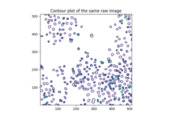

[Segment human cells (in mitosis)](https://scikit-image.org/docs/0.18.x/auto_examples/applications/plot_human_mitosis.html#sphx-glr-auto-examples-applications-plot-human-mitosis-py)

[Rank filters](https://scikit-image.org/docs/0.18.x/auto_examples/applications/plot_rank_filters.html#sphx-glr-auto-examples-applications-plot-rank-filters-py)

## mean_bilateral

**`skimage.filters.rank.mean_bilateral(image, selem, out=None, mask=None, shift_x=False, shift_y=False, s0=10, s1=10)` [[source]](https://github.com/scikit-image/scikit-image/blob/v0.18.0/skimage/filters/rank/bilateral.py#L47-L102)**

Apply a flat kernel bilateral filter.

This is an edge-preserving and noise reducing denoising filter. It averages pixels based on their spatial closeness and radiometric similarity.

Spatial closeness is measured by considering only the local pixel neighborhood given by a structuring element.

Radiometric similarity is defined by the greylevel interval [g-s0, g+s1] where g is the current pixel greylevel.

Only pixels belonging to the structuring element and having a greylevel inside this interval are averaged.

**Parameters**

**`image2-D array (uint8, uint16)`**

Input image.

**`selem2-D array`**

The neighborhood expressed as a 2-D array of 1’s and 0’s.

**`out2-D array (same dtype as input)`**

If None, a new array is allocated.

**`maskndarray`**

Mask array that defines (>0) area of the image included in the local neighborhood. If None, the complete image is used (default).

**`shift_x, shift_yint`**

Offset added to the structuring element center point. Shift is bounded to the structuring element sizes (center must be inside the given structuring element).

**`s0, s1int`**

Define the [s0, s1] interval around the greyvalue of the center pixel to be considered for computing the value.

**Returns**

**`out2-D array (same dtype as input image)`**

Output image.

See also

**`denoise_bilateral`**

#### Examples

```
>>> from skimage import data
>>> from skimage.morphology import disk
>>> from skimage.filters.rank import mean_bilateral
>>> img = data.camera().astype(np.uint16)
>>> bilat_img = mean_bilateral(img, disk(20), s0=10,s1=10)
```

### Examples using `skimage.filters.rank.mean_bilateral`

[Rank filters](https://scikit-image.org/docs/0.18.x/auto_examples/applications/plot_rank_filters.html#sphx-glr-auto-examples-applications-plot-rank-filters-py)

## mean_percentile

**`skimage.filters.rank.mean_percentile(image, selem, out=None, mask=None, shift_x=False, shift_y=False, p0=0, p1=1)` [[source]](https://github.com/scikit-image/scikit-image/blob/v0.18.0/skimage/filters/rank/_percentile.py#L125-L159)**

Return local mean of an image.

Only greyvalues between percentiles [p0, p1] are considered in the filter.

**Parameters**

**`image2-D array (uint8, uint16)`**

Input image.

**`selem2-D array`**

The neighborhood expressed as a 2-D array of 1’s and 0’s.

**`out2-D array (same dtype as input)`**

If None, a new array is allocated.

**`maskndarray`**

Mask array that defines (>0) area of the image included in the local neighborhood. If None, the complete image is used (default).

**`shift_x, shift_yint`**

Offset added to the structuring element center point. Shift is bounded to the structuring element sizes (center must be inside the given structuring element).

**`p0, p1float in [0, …, 1]`**

Define the [p0, p1] percentile interval to be considered for computing the value.

**Returns**

**`out2-D array (same dtype as input image)`**

Output image.

## median

**`skimage.filters.rank.median(image, selem=None, out=None, mask=None, shift_x=False, shift_y=False, shift_z=False)` [[source]](https://github.com/scikit-image/scikit-image/blob/v0.18.0/skimage/filters/rank/generic.py#L768-L823)**

Return local median of an image.

**Parameters**

**`image([P,] M, N) ndarray (uint8, uint16)`**

Input image.

**`selemndarray`**

The neighborhood expressed as an ndarray of 1’s and 0’s. If None, a full square of size 3 is used.

**`out([P,] M, N) array (same dtype as input)`**

If None, a new array is allocated.

**`maskndarray (integer or float), optional`**

Mask array that defines (>0) area of the image included in the local neighborhood. If None, the complete image is used (default).

**`shift_x, shift_y, shift_zint`**

Offset added to the structuring element center point. Shift is bounded to the structuring element sizes (center must be inside the given structuring element).

**Returns**

**`out([P,] M, N) ndarray (same dtype as input image)`**

Output image.

See also

**`skimage.filters.median`**

Implementation of a median filtering which handles images with floating precision.

#### Examples

```
>>> from skimage import data
>>> from skimage.morphology import disk, ball
>>> from skimage.filters.rank import median
>>> import numpy as np
>>> img = data.camera()
>>> volume = np.random.randint(0, 255, size=(10,10,10), dtype=np.uint8)
>>> med = median(img, disk(5))
>>> med_vol = median(volume, ball(5))
```

### Examples using `skimage.filters.rank.median`

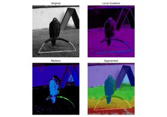

[Markers for watershed transform](https://scikit-image.org/docs/0.18.x/auto_examples/segmentation/plot_marked_watershed.html#sphx-glr-auto-examples-segmentation-plot-marked-watershed-py)

[Rank filters](https://scikit-image.org/docs/0.18.x/auto_examples/applications/plot_rank_filters.html#sphx-glr-auto-examples-applications-plot-rank-filters-py)

## minimum

**`skimage.filters.rank.minimum(image, selem, out=None, mask=None, shift_x=False, shift_y=False, shift_z=False)` [[source]](https://github.com/scikit-image/scikit-image/blob/v0.18.0/skimage/filters/rank/generic.py#L826-L882)**

Return local minimum of an image.

**Parameters**

**`image([P,] M, N) ndarray (uint8, uint16)`**

Input image.

**`selemndarray`**

The neighborhood expressed as an ndarray of 1’s and 0’s.

**`out([P,] M, N) array (same dtype as input)`**

If None, a new array is allocated.

**`maskndarray (integer or float), optional`**

Mask array that defines (>0) area of the image included in the local neighborhood. If None, the complete image is used (default).

**`shift_x, shift_y, shift_zint`**

Offset added to the structuring element center point. Shift is bounded to the structuring element sizes (center must be inside the given structuring element).

**Returns**

**`out([P,] M, N) ndarray (same dtype as input image)`**

Output image.

See also

**`skimage.morphology.erosion`**

#### Notes

The lower algorithm complexity makes `skimage.filters.rank.minimum` more efficient for larger images and structuring elements.

#### Examples

```
>>> from skimage import data
>>> from skimage.morphology import disk, ball
>>> from skimage.filters.rank import minimum
>>> import numpy as np
>>> img = data.camera()
>>> volume = np.random.randint(0, 255, size=(10,10,10), dtype=np.uint8)
>>> out = minimum(img, disk(5))
>>> out_vol = minimum(volume, ball(5))
```

### Examples using `skimage.filters.rank.minimum`

[Rank filters](https://scikit-image.org/docs/0.18.x/auto_examples/applications/plot_rank_filters.html#sphx-glr-auto-examples-applications-plot-rank-filters-py)

## modal

**`skimage.filters.rank.modal(image, selem, out=None, mask=None, shift_x=False, shift_y=False, shift_z=False)` [[source]](https://github.com/scikit-image/scikit-image/blob/v0.18.0/skimage/filters/rank/generic.py#L885-L934)**

Return local mode of an image.

The mode is the value that appears most often in the local histogram.

**Parameters**

**`image([P,] M, N) ndarray (uint8, uint16)`**

Input image.

**`selemndarray`**

The neighborhood expressed as an ndarray of 1’s and 0’s.

**`out([P,] M, N) array (same dtype as input)`**

If None, a new array is allocated.

**`maskndarray (integer or float), optional`**

Mask array that defines (>0) area of the image included in the local neighborhood. If None, the complete image is used (default).

**`shift_x, shift_y, shift_zint`**

Offset added to the structuring element center point. Shift is bounded to the structuring element sizes (center must be inside the given structuring element).

**Returns**

**`out([P,] M, N) ndarray (same dtype as input image)`**

Output image.

#### Examples

```
>>> from skimage import data
>>> from skimage.morphology import disk, ball
>>> from skimage.filters.rank import modal
>>> import numpy as np
>>> img = data.camera()
>>> volume = np.random.randint(0, 255, size=(10,10,10), dtype=np.uint8)
>>> out = modal(img, disk(5))
>>> out_vol = modal(volume, ball(5))
```

## noise_filter

**`skimage.filters.rank.noise_filter(image, selem, out=None, mask=None, shift_x=False, shift_y=False, shift_z=False)` [[source]](https://github.com/scikit-image/scikit-image/blob/v0.18.0/skimage/filters/rank/generic.py#L1220-L1287)**

Noise feature.

**Parameters**

**`image([P,] M, N) ndarray (uint8, uint16)`**

Input image.

**`selemndarray`**

The neighborhood expressed as an ndarray of 1’s and 0’s.

**`out([P,] M, N) array (same dtype as input)`**

If None, a new array is allocated.

**`maskndarray (integer or float), optional`**

Mask array that defines (>0) area of the image included in the local neighborhood. If None, the complete image is used (default).

**`shift_x, shift_y, shift_zint`**

Offset added to the structuring element center point. Shift is bounded to the structuring element sizes (center must be inside the given structuring element).

**Returns**

**`out([P,] M, N) ndarray (same dtype as input image)`**

Output image.

#### References

**`1`**

N. Hashimoto et al. Referenceless image quality evaluation for whole slide imaging. J Pathol Inform 2012;3:9.

#### Examples

```
>>> from skimage import data
>>> from skimage.morphology import disk, ball
>>> from skimage.filters.rank import noise_filter
>>> import numpy as np
>>> img = data.camera()
>>> volume = np.random.randint(0, 255, size=(10,10,10), dtype=np.uint8)
>>> out = noise_filter(img, disk(5))
>>> out_vol = noise_filter(volume, ball(5))
```

## otsu

**`skimage.filters.rank.otsu(image, selem, out=None, mask=None, shift_x=False, shift_y=False, shift_z=False)` [[source]](https://github.com/scikit-image/scikit-image/blob/v0.18.0/skimage/filters/rank/generic.py#L1349-L1402)**

Local Otsu’s threshold value for each pixel.

**Parameters**

**`image([P,] M, N) ndarray (uint8, uint16)`**

Input image.

**`selemndarray`**

The neighborhood expressed as an ndarray of 1’s and 0’s.

**`out([P,] M, N) array (same dtype as input)`**

If None, a new array is allocated.

**`maskndarray (integer or float), optional`**

Mask array that defines (>0) area of the image included in the local neighborhood. If None, the complete image is used (default).

**`shift_x, shift_y, shift_zint`**

Offset added to the structuring element center point. Shift is bounded to the structuring element sizes (center must be inside the given structuring element).

**Returns**

**`out([P,] M, N) ndarray (same dtype as input image)`**

Output image.

#### References

**`1`**

[https://en.wikipedia.org/wiki/Otsu’s_method](https://en.wikipedia.org/wiki/Otsu's_method)

#### Examples

```
>>> from skimage import data
>>> from skimage.filters.rank import otsu
>>> from skimage.morphology import disk, ball
>>> import numpy as np
>>> img = data.camera()
>>> volume = np.random.randint(0, 255, size=(10,10,10), dtype=np.uint8)
>>> local_otsu = otsu(img, disk(5))
>>> thresh_image = img >= local_otsu
>>> local_otsu_vol = otsu(volume, ball(5))
>>> thresh_image_vol = volume >= local_otsu_vol
```

### Examples using `skimage.filters.rank.otsu`

[Rank filters](https://scikit-image.org/docs/0.18.x/auto_examples/applications/plot_rank_filters.html#sphx-glr-auto-examples-applications-plot-rank-filters-py)

## percentile

**`skimage.filters.rank.percentile(image, selem, out=None, mask=None, shift_x=False, shift_y=False, p0=0)` [[source]](https://github.com/scikit-image/scikit-image/blob/v0.18.0/skimage/filters/rank/_percentile.py#L240-L276)**

Return local percentile of an image.

Returns the value of the p0 lower percentile of the local greyvalue distribution.

Only greyvalues between percentiles [p0, p1] are considered in the filter.

**Parameters**

**`image2-D array (uint8, uint16)`**

Input image.

**`selem2-D array`**

The neighborhood expressed as a 2-D array of 1’s and 0’s.

**`out2-D array (same dtype as input)`**

If None, a new array is allocated.

**`maskndarray`**

Mask array that defines (>0) area of the image included in the local neighborhood. If None, the complete image is used (default).

**`shift_x, shift_yint`**

Offset added to the structuring element center point. Shift is bounded to the structuring element sizes (center must be inside the given structuring element).

**`p0float in [0, …, 1]`**

Set the percentile value.

**Returns**

**`out2-D array (same dtype as input image)`**

Output image.

## pop

**`skimage.filters.rank.pop(image, selem, out=None, mask=None, shift_x=False, shift_y=False, shift_z=False)` [[source]](https://github.com/scikit-image/scikit-image/blob/v0.18.0/skimage/filters/rank/generic.py#L991-L1046)**

Return the local number (population) of pixels.

The number of pixels is defined as the number of pixels which are included in the structuring element and the mask.

**Parameters**

**`image([P,] M, N) ndarray (uint8, uint16)`**

Input image.

**`selemndarray`**

The neighborhood expressed as an ndarray of 1’s and 0’s.

**`out([P,] M, N) array (same dtype as input)`**

If None, a new array is allocated.

**`maskndarray (integer or float), optional`**

Mask array that defines (>0) area of the image included in the local neighborhood. If None, the complete image is used (default).

**`shift_x, shift_y, shift_zint`**

Offset added to the structuring element center point. Shift is bounded to the structuring element sizes (center must be inside the given structuring element).

**Returns**

**`out([P,] M, N) ndarray (same dtype as input image)`**

Output image.

#### Examples

```
>>> from skimage.morphology import square, cube # Need to add 3D example
>>> import skimage.filters.rank as rank
>>> img = 255 * np.array([[0, 0, 0, 0, 0],
...                       [0, 1, 1, 1, 0],
...                       [0, 1, 1, 1, 0],
...                       [0, 1, 1, 1, 0],
...                       [0, 0, 0, 0, 0]], dtype=np.uint8)
>>> rank.pop(img, square(3))
array([[4, 6, 6, 6, 4],
       [6, 9, 9, 9, 6],
       [6, 9, 9, 9, 6],
       [6, 9, 9, 9, 6],
       [4, 6, 6, 6, 4]], dtype=uint8)
```

## pop_bilateral

**`skimage.filters.rank.pop_bilateral(image, selem, out=None, mask=None, shift_x=False, shift_y=False, s0=10, s1=10)` [[source]](https://github.com/scikit-image/scikit-image/blob/v0.18.0/skimage/filters/rank/bilateral.py#L105-L158)**

Return the local number (population) of pixels.

The number of pixels is defined as the number of pixels which are included in the structuring element and the mask. Additionally pixels must have a greylevel inside the interval [g-s0, g+s1] where g is the greyvalue of the center pixel.

**Parameters**

**`image2-D array (uint8, uint16)`**

Input image.

**`selem2-D array`**

The neighborhood expressed as a 2-D array of 1’s and 0’s.

**`out2-D array (same dtype as input)`**

If None, a new array is allocated.

**`maskndarray`**

Mask array that defines (>0) area of the image included in the local neighborhood. If None, the complete image is used (default).

**`shift_x, shift_yint`**

Offset added to the structuring element center point. Shift is bounded to the structuring element sizes (center must be inside the given structuring element).

**`s0, s1int`**

Define the [s0, s1] interval around the greyvalue of the center pixel to be considered for computing the value.

**Returns**

**`out2-D array (same dtype as input image)`**

Output image.

#### Examples

```
>>> from skimage.morphology import square
>>> import skimage.filters.rank as rank
>>> img = 255 * np.array([[0, 0, 0, 0, 0],
...                       [0, 1, 1, 1, 0],
...                       [0, 1, 1, 1, 0],
...                       [0, 1, 1, 1, 0],
...                       [0, 0, 0, 0, 0]], dtype=np.uint16)
>>> rank.pop_bilateral(img, square(3), s0=10, s1=10)
array([[3, 4, 3, 4, 3],
       [4, 4, 6, 4, 4],
       [3, 6, 9, 6, 3],
       [4, 4, 6, 4, 4],
       [3, 4, 3, 4, 3]], dtype=uint16)
```

## pop_percentile

**`skimage.filters.rank.pop_percentile(image, selem, out=None, mask=None, shift_x=False, shift_y=False, p0=0, p1=1)` [[source]](https://github.com/scikit-image/scikit-image/blob/v0.18.0/skimage/filters/rank/_percentile.py#L279-L316)**

Return the local number (population) of pixels.

The number of pixels is defined as the number of pixels which are included in the structuring element and the mask.

Only greyvalues between percentiles [p0, p1] are considered in the filter.

**Parameters**

**`image2-D array (uint8, uint16)`**

Input image.

**`selem2-D array`**

The neighborhood expressed as a 2-D array of 1’s and 0’s.

**`out2-D array (same dtype as input)`**

If None, a new array is allocated.

**`maskndarray`**

Mask array that defines (>0) area of the image included in the local neighborhood. If None, the complete image is used (default).

**`shift_x, shift_yint`**

Offset added to the structuring element center point. Shift is bounded to the structuring element sizes (center must be inside the given structuring element).

**`p0, p1float in [0, …, 1]`**

Define the [p0, p1] percentile interval to be considered for computing the value.

**Returns**

**`out2-D array (same dtype as input image)`**

Output image.

## subtract_mean

**`skimage.filters.rank.subtract_mean(image, selem, out=None, mask=None, shift_x=False, shift_y=False, shift_z=False)` [[source]](https://github.com/scikit-image/scikit-image/blob/v0.18.0/skimage/filters/rank/generic.py#L710-L765)**

Return image subtracted from its local mean.

**Parameters**

**`image([P,] M, N) ndarray (uint8, uint16)`**

Input image.

**`selemndarray`**

The neighborhood expressed as an ndarray of 1’s and 0’s.

**`out([P,] M, N) array (same dtype as input)`**

If None, a new array is allocated.

**`maskndarray (integer or float), optional`**

Mask array that defines (>0) area of the image included in the local neighborhood. If None, the complete image is used (default).

**`shift_x, shift_y, shift_zint`**

Offset added to the structuring element center point. Shift is bounded to the structuring element sizes (center must be inside the given structuring element).

**Returns**

**`out([P,] M, N) ndarray (same dtype as input image)`**

Output image.

#### Notes

Subtracting the mean value may introduce underflow. To compensate this potential underflow, the obtained difference is downscaled by a factor of 2 and shifted by `n_bins / 2 - 1`, the median value of the local histogram (`n_bins = max(3, image.max()) +1` for 16-bits images and 256 otherwise).

#### Examples

```
>>> from skimage import data
>>> from skimage.morphology import disk, ball
>>> from skimage.filters.rank import subtract_mean
>>> import numpy as np
>>> img = data.camera()
>>> volume = np.random.randint(0, 255, size=(10,10,10), dtype=np.uint8)
>>> out = subtract_mean(img, disk(5))
>>> out_vol = subtract_mean(volume, ball(5))
```

## subtract_mean_percentile

**`skimage.filters.rank.subtract_mean_percentile(image, selem, out=None, mask=None, shift_x=False, shift_y=False, p0=0, p1=1)` [[source]](https://github.com/scikit-image/scikit-image/blob/v0.18.0/skimage/filters/rank/_percentile.py#L162-L196)**

Return image subtracted from its local mean.

Only greyvalues between percentiles [p0, p1] are considered in the filter.

**Parameters**

**`image2-D array (uint8, uint16)`**

Input image.

**`selem2-D array`**

The neighborhood expressed as a 2-D array of 1’s and 0’s.

**`out2-D array (same dtype as input)`**

If None, a new array is allocated.

**`maskndarray`**

Mask array that defines (>0) area of the image included in the local neighborhood. If None, the complete image is used (default).

**`shift_x, shift_yint`**

Offset added to the structuring element center point. Shift is bounded to the structuring element sizes (center must be inside the given structuring element).

**`p0, p1float in [0, …, 1]`**

Define the [p0, p1] percentile interval to be considered for computing the value.

**Returns**

**`out2-D array (same dtype as input image)`**

Output image.

## sum

**`skimage.filters.rank.sum(image, selem, out=None, mask=None, shift_x=False, shift_y=False, shift_z=False)` [[source]](https://github.com/scikit-image/scikit-image/blob/v0.18.0/skimage/filters/rank/generic.py#L1049-L1104)**

Return the local sum of pixels.

Note that the sum may overflow depending on the data type of the input array.

**Parameters**

**`image([P,] M, N) ndarray (uint8, uint16)`**

Input image.

**`selemndarray`**

The neighborhood expressed as an ndarray of 1’s and 0’s.

**`out([P,] M, N) array (same dtype as input)`**

If None, a new array is allocated.

**`maskndarray (integer or float), optional`**

Mask array that defines (>0) area of the image included in the local neighborhood. If None, the complete image is used (default).

**`shift_x, shift_y, shift_zint`**

Offset added to the structuring element center point. Shift is bounded to the structuring element sizes (center must be inside the given structuring element).

**Returns**

**`out([P,] M, N) ndarray (same dtype as input image)`**

Output image.

#### Examples

```
>>> from skimage.morphology import square, cube # Need to add 3D example
>>> import skimage.filters.rank as rank         # Cube seems to fail but
>>> img = np.array([[0, 0, 0, 0, 0],            # Ball can pass
...                 [0, 1, 1, 1, 0],
...                 [0, 1, 1, 1, 0],
...                 [0, 1, 1, 1, 0],
...                 [0, 0, 0, 0, 0]], dtype=np.uint8)
>>> rank.sum(img, square(3))
array([[1, 2, 3, 2, 1],
       [2, 4, 6, 4, 2],
       [3, 6, 9, 6, 3],
       [2, 4, 6, 4, 2],
       [1, 2, 3, 2, 1]], dtype=uint8)
```

## sum_bilateral

**`skimage.filters.rank.sum_bilateral(image, selem, out=None, mask=None, shift_x=False, shift_y=False, s0=10, s1=10)` [[source]](https://github.com/scikit-image/scikit-image/blob/v0.18.0/skimage/filters/rank/bilateral.py#L161-L219)**

Apply a flat kernel bilateral filter.

This is an edge-preserving and noise reducing denoising filter. It averages pixels based on their spatial closeness and radiometric similarity.

Spatial closeness is measured by considering only the local pixel neighborhood given by a structuring element (selem).

Radiometric similarity is defined by the greylevel interval [g-s0, g+s1] where g is the current pixel greylevel.

Only pixels belonging to the structuring element AND having a greylevel inside this interval are summed.

Note that the sum may overflow depending on the data type of the input array.

**Parameters**

**`image2-D array (uint8, uint16)`**

Input image.

**`selem2-D array`**

The neighborhood expressed as a 2-D array of 1’s and 0’s.

**`out2-D array (same dtype as input)`**

If None, a new array is allocated.

**`maskndarray`**

Mask array that defines (>0) area of the image included in the local neighborhood. If None, the complete image is used (default).

**`shift_x, shift_yint`**

Offset added to the structuring element center point. Shift is bounded to the structuring element sizes (center must be inside the given structuring element).

**`s0, s1int`**

Define the [s0, s1] interval around the greyvalue of the center pixel to be considered for computing the value.

**Returns**

**`out2-D array (same dtype as input image)`**

Output image.

See also

**`denoise_bilateral`**

#### Examples

```
>>> from skimage import data
>>> from skimage.morphology import disk
>>> from skimage.filters.rank import sum_bilateral
>>> img = data.camera().astype(np.uint16)
>>> bilat_img = sum_bilateral(img, disk(10), s0=10, s1=10)
```

## sum_percentile

**`skimage.filters.rank.sum_percentile(image, selem, out=None, mask=None, shift_x=False, shift_y=False, p0=0, p1=1)` [[source]](https://github.com/scikit-image/scikit-image/blob/v0.18.0/skimage/filters/rank/_percentile.py#L319-L356)**

Return the local sum of pixels.

Only greyvalues between percentiles [p0, p1] are considered in the filter.

Note that the sum may overflow depending on the data type of the input array.

**Parameters**

**`image2-D array (uint8, uint16)`**

Input image.

**`selem2-D array`**

The neighborhood expressed as a 2-D array of 1’s and 0’s.

**`out2-D array (same dtype as input)`**

If None, a new array is allocated.

**`maskndarray`**

Mask array that defines (>0) area of the image included in the local neighborhood. If None, the complete image is used (default).

**`shift_x, shift_yint`**

Offset added to the structuring element center point. Shift is bounded to the structuring element sizes (center must be inside the given structuring element).

**`p0, p1float in [0, …, 1]`**

Define the [p0, p1] percentile interval to be considered for computing the value.

**Returns**

**`out2-D array (same dtype as input image)`**

Output image.

## threshold

**`skimage.filters.rank.threshold(image, selem, out=None, mask=None, shift_x=False, shift_y=False, shift_z=False)` [[source]](https://github.com/scikit-image/scikit-image/blob/v0.18.0/skimage/filters/rank/generic.py#L1107-L1162)**

Local threshold of an image.

The resulting binary mask is True if the gray value of the center pixel is greater than the local mean.

**Parameters**

**`image([P,] M, N) ndarray (uint8, uint16)`**

Input image.

**`selemndarray`**

The neighborhood expressed as an ndarray of 1’s and 0’s.

**`out([P,] M, N) array (same dtype as input)`**

If None, a new array is allocated.

**`maskndarray (integer or float), optional`**

Mask array that defines (>0) area of the image included in the local neighborhood. If None, the complete image is used (default).

**`shift_x, shift_y, shift_zint`**

Offset added to the structuring element center point. Shift is bounded to the structuring element sizes (center must be inside the given structuring element).

**Returns**

**`out([P,] M, N) ndarray (same dtype as input image)`**

Output image.

#### Examples

```
>>> from skimage.morphology import square, cube # Need to add 3D example
>>> from skimage.filters.rank import threshold
>>> img = 255 * np.array([[0, 0, 0, 0, 0],
...                       [0, 1, 1, 1, 0],
...                       [0, 1, 1, 1, 0],
...                       [0, 1, 1, 1, 0],
...                       [0, 0, 0, 0, 0]], dtype=np.uint8)
>>> threshold(img, square(3))
array([[0, 0, 0, 0, 0],
       [0, 1, 1, 1, 0],
       [0, 1, 0, 1, 0],
       [0, 1, 1, 1, 0],
       [0, 0, 0, 0, 0]], dtype=uint8)
```

## threshold_percentile

**`skimage.filters.rank.threshold_percentile(image, selem, out=None, mask=None, shift_x=False, shift_y=False, p0=0)` [[source]](https://github.com/scikit-image/scikit-image/blob/v0.18.0/skimage/filters/rank/_percentile.py#L359-L395)**

Local threshold of an image.

The resulting binary mask is True if the greyvalue of the center pixel is greater than the local mean.

Only greyvalues between percentiles [p0, p1] are considered in the filter.

**Parameters**

**`image2-D array (uint8, uint16)`**

Input image.

**`selem2-D array`**

The neighborhood expressed as a 2-D array of 1’s and 0’s.

**`out2-D array (same dtype as input)`**

If None, a new array is allocated.

**`maskndarray`**

Mask array that defines (>0) area of the image included in the local neighborhood. If None, the complete image is used (default).

**`shift_x, shift_yint`**

Offset added to the structuring element center point. Shift is bounded to the structuring element sizes (center must be inside the given structuring element).

**`p0float in [0, …, 1]`**

Set the percentile value.

**Returns**

**`out2-D array (same dtype as input image)`**

Output image.

## tophat

**`skimage.filters.rank.tophat(image, selem, out=None, mask=None, shift_x=False, shift_y=False)` [[source]](https://github.com/scikit-image/scikit-image/blob/v0.18.0/skimage/filters/rank/generic.py#L1165-L1217)**

Local top-hat of an image.

This filter computes the morphological opening of the image and then subtracts the result from the original image.

**Parameters**

**`image2-D array (integer or float)`**

Input image.

**`selem2-D array (integer or float)`**

The neighborhood expressed as a 2-D array of 1’s and 0’s.

**`out2-D array (integer or float), optional`**

If None, a new array is allocated.

**`maskndarray (integer or float), optional`**

Mask array that defines (>0) area of the image included in the local neighborhood. If None, the complete image is used (default).

**`shift_x, shift_yint, optional`**

Offset added to the structuring element center point. Shift is bounded to the structuring element sizes (center must be inside the given structuring element).

**Returns**

**`out2-D array (same dtype as input image)`**

Output image.

**Warns**

**Deprecated:**

New in version 0.17.

This function is deprecated and will be removed in scikit-image 0.19. This filter was misnamed and we believe that the usefulness is narrow.

#### Examples

```
>>> from skimage import data
>>> from skimage.morphology import disk
>>> from skimage.filters.rank import tophat
>>> img = data.camera()
>>> out = tophat(img, disk(5))
```

## windowed_histogram

**`skimage.filters.rank.windowed_histogram(image, selem, out=None, mask=None, shift_x=False, shift_y=False, n_bins=None)` [[source]](https://github.com/scikit-image/scikit-image/blob/v0.18.0/skimage/filters/rank/generic.py#L1405-L1457)**

Normalized sliding window histogram

**Parameters**

**`image2-D array (integer or float)`**

Input image.

**`selem2-D array (integer or float)`**

The neighborhood expressed as a 2-D array of 1’s and 0’s.

**`out2-D array (integer or float), optional`**

If None, a new array is allocated.

**`maskndarray (integer or float), optional`**

Mask array that defines (>0) area of the image included in the local neighborhood. If None, the complete image is used (default).

**`shift_x, shift_yint, optional`**

Offset added to the structuring element center point. Shift is bounded to the structuring element sizes (center must be inside the given structuring element).

**`n_binsint or None`**

The number of histogram bins. Will default to `image.max() + 1` if None is passed.

**Returns**

**`out3-D array (float)`**

Array of dimensions (H,W,N), where (H,W) are the dimensions of the input image and N is n_bins or `image.max() + 1` if no value is provided as a parameter. Effectively, each pixel is a N-D feature vector that is the histogram. The sum of the elements in the feature vector will be 1, unless no pixels in the window were covered by both selem and mask, in which case all elements will be 0.

#### Examples

```
>>> from skimage import data
>>> from skimage.filters.rank import windowed_histogram
>>> from skimage.morphology import disk, ball
>>> import numpy as np
>>> img = data.camera()
>>> volume = np.random.randint(0, 255, size=(10,10,10), dtype=np.uint8)
>>> hist_img = windowed_histogram(img, disk(5))
```

© 2019 the scikit-image team  
Licensed under the BSD 3-clause License.  
https://scikit-image.org/docs/0.18.x/api/skimage.filters.rank.html